# Supplement

Xiaoyang Li

2020/11/29

## data

```r
data = read_csv("./data/Clean_Join.csv") %>%  select(-X1, -MCATOT )
PD_BL = data %>% filter(APPRDX == "PD",
                        EVENT_ID == "BL") # 423 patients

new = merge(data, PD_BL, by = "PATNO", all = FALSE) [,1:146]

PD_V04 = new %>% filter(EVENT_ID.x == "V04") # 391 patients
PD_V14 = new %>% filter(EVENT_ID.x == "V14") # 239 patients

PD_V04 = tibble(PD_V04)
PD_V14 = tibble(PD_V14)


# regression

regdata = read_csv("./data/Clean_Join.csv") %>%select(PATNO, EVENT_ID, APPRDX, MCATOT )
regPD = data %>% filter(APPRDX == "PD",
                        EVENT_ID == "BL")
regnew = merge(regdata, regPD, by = "PATNO", all = FALSE) %>%select(PATNO, EVENT_ID.x, MCATOT )
regnew = na.omit(regnew)

reg_V04 = regnew %>% filter(EVENT_ID.x == "V04") # 365 patients
reg_V04 = merge(PD_V04, reg_V04) %>%select(PATNO,EVENT_ID.x, APPRDX.x, MCATOT ) %>% tibble()
PD_V04 = merge(PD_V04, reg_V04) %>%select(-MCATOT, -APPRDX.x, -PRIMDIAG.x ) %>% tibble()

reg_V14 = regnew %>% filter(EVENT_ID.x == "V14") # 234 patients
reg_V14 = merge(PD_V14, reg_V14) %>%select(PATNO, EVENT_ID.x, APPRDX.x, MCATOT ) %>% tibble()
PD_V14 =  merge(PD_V14, reg_V14) %>%select(- MCATOT, -APPRDX.x, -PRIMDIAG.x ) %>% tibble()


# LDA
V04 = PD_V04 %>%
  pivot_longer(HISPLAT.x:mctot.x, names_to = "Variable", values_to = "word") %>%
  filter(is.na(word) == FALSE)

V04dfm = V04 %>% group_by(PATNO,word) %>% count() %>%
  cast_dfm(PATNO, word, n)

V14 = PD_V14 %>%
  pivot_longer(HISPLAT.x:mctot.x, names_to = "Variable", values_to = "word") %>%
  filter(is.na(word) == FALSE)

V14dfm = V14 %>% group_by(PATNO,word) %>% count() %>%
  cast_dfm(PATNO, word, n)

# UPDRS
UPDRS = read_csv(file = "./data/UPDRS.csv") %>% select(-X1)
UPDRS$updrstot = rowSums(UPDRS[,16:62])
UPDRS = UPDRS %>% select(updrstot, everything())
UPDRS_V04 = UPDRS %>% filter(EVENT_ID == "V04") %>% merge(PD_V04, by  = "PATNO") %>%select(updrstot, PATNO, EVENT_ID) %>% na.omit() #359
UPDRS_V14 = UPDRS %>% filter(EVENT_ID == "V14") %>% merge(PD_V14, by  = "PATNO") %>%select(updrstot, PATNO,EVENT_ID) %>% na.omit() #231
```

## Supplement

I found that baseline variables are lack of information about MOCA, so I rebuild topic models at V04 and V14 based on the package lda.

**Specify Hyperparameter: alpha and eta**

Hyperparameter alpha controls the shape of the document–topic distribution, whereas eta controls the shape of the topic–word distribution. A large alpha leads to documents containing many topics, and a large eta leads to topics with many words.

Refer: Selecting Priors for Latent Dirichlet Allocation http://www.saf21.eu/wp-content/uploads/2018/02/Selecting-Priors-for-Latent-Dirichlet-Allocation.pdf

```r
eta = 1/3
alpha = 1/280

# V04

V04dfmlda = convert(V04dfm, to = "lda")

V04fit = lda.collapsed.gibbs.sampler(V04dfmlda$documents, K= 3, vocab = V04dfmlda$vocab, num.iterations = 1000, alpha  ,eta, initial = NULL, burnin = NULL, compute.log.likelihood = FALSE)

V04docusum = V04fit$document_sums

V04pre = predictive.distribution(V04fit$document_sums, V04fit$topics, alpha, eta)


# V14

V14dfmlda = convert(V14dfm, to = "lda")

V14fit = lda.collapsed.gibbs.sampler(V14dfmlda$documents, K= 3, vocab = V14dfmlda$vocab, num.iterations = 1000, alpha = 0.02 ,eta = 0.02, initial = NULL, burnin = NULL, compute.log.likelihood = FALSE)


V14docusum = V14fit$document_sums


## prediction distribution
V14pre = predictive.distribution(V14fit$document_sums, V14fit$topics, alpha, eta)
```

### Regression

Using the weights from the topic model (posterior probability of a patient belonging to each topic) for each patient as covariate to predict follow up outcomes. The weights should be part of the topic model outputs. If we have 3 topics, we only need to include weights for 2 topics. The follow up outcomes will be motor (UPDRS total score) or cognitive symptom scores (Moca or SDMT) at follow up visits

- Using cognitive symptom scores as response

```r
V04prob = t(V04docusum)
colnames(V04prob) = c("n1", "n2", "n3")
V04prob = V04prob %>% as_tibble() %>%
  mutate(V04p1 = n1 / (n1+n2+n3),
         V04p2 = n2 / (n1+n2+n3),
         V04p3 = n3 / (n1+n2+n3))
reg_V04_ = cbind(reg_V04, V04prob) %>% rename(V04MCATOT = MCATOT)

V14prob = t(V14docusum)
colnames(V14prob) = c("n1", "n2", "n3")
V14prob = V14prob %>% as_tibble() %>%
  mutate(V14p1 = n1 / (n1+n2+n3),
         V14p2 = n2 / (n1+n2+n3),
         V14p3 = n3 / (n1+n2+n3))
reg_V14_ = cbind(reg_V14, V14prob) %>% rename(V14MCATOT = MCATOT)

reg_com = reg_V04_ %>% merge( reg_V14_, by = "PATNO")
```

Response: cognitive symptom scores (MCATOT) at V04 Covariate: probability of each V04 topic model

```r
glm_V04 = glm(V04MCATOT~ V04p1+V04p2, data = reg_V04_)
summary(glm_V04)
```

```
##
## Call:
## glm(formula = V04MCATOT ~ V04p1 + V04p2, data = reg_V04_)
##
## Deviance Residuals:
##      Min        1Q    Median        3Q       Max
## -10.6817   -1.6817    0.5223    1.9981    4.7080
##
## Coefficients:
##             Estimate Std. Error t value Pr(>|t|)
## (Intercept)  25.6817     0.3202  80.197  < 2e-16 ***
## V04p1         1.3202     0.3775   3.497 0.000529 ***
## V04p2        -0.3897     0.4354  -0.895 0.371361
## ---
## Signif. codes:  0 '***' 0.001 '**' 0.01 '*' 0.05 '.' 0.1 ' ' 1
##
## (Dispersion parameter for gaussian family taken to be 7.306559)
##
##     Null deviance: 2853.5  on 364  degrees of freedom
## Residual deviance: 2645.0  on 362  degrees of freedom
## AIC: 1766.7
##
## Number of Fisher Scoring iterations: 2
```

Response: cognitive symptom scores (MCATOT) at V14 Covariate: probability of each V14 topic model

```r
glm_V14 = glm(V14MCATOT~ V14p1+V14p2, data = reg_V14_)
summary(glm_V14)
```

```
##
## Call:
## glm(formula = V14MCATOT ~ V14p1 + V14p2, data = reg_V14_)
##
## Deviance Residuals:
##      Min        1Q    Median        3Q       Max
## -12.7224   -1.6642    0.5197    2.1205    7.7696
##
## Coefficients:
##             Estimate Std. Error t value Pr(>|t|)
## (Intercept)    3.047      2.557   1.192    0.235
## V14p1         26.211      2.883   9.093   <2e-16 ***
## V14p2         24.600      2.639   9.321   <2e-16 ***
## ---
## Signif. codes:  0 '***' 0.001 '**' 0.01 '*' 0.05 '.' 0.1 ' ' 1
##
## (Dispersion parameter for gaussian family taken to be 9.619887)
##
##     Null deviance: 3060.6  on 233  degrees of freedom
## Residual deviance: 2222.2  on 231  degrees of freedom
## AIC: 1198.8
##
## Number of Fisher Scoring iterations: 2
```

Response: cognitive symptom scores (MCATOT) at V14 Covariate: probability of each V04 and V14 topic model

```r
glm_com = glm(V14MCATOT~ V04p1 +V04p2 + V14p1+V14p2, data = reg_com)
summary(glm_com)
```

```
##
## Call:
## glm(formula = V14MCATOT ~ V04p1 + V04p2 + V14p1 + V14p2, data = reg_com)
##
## Deviance Residuals:
##     Min       1Q   Median       3Q      Max
## -11.548   -1.720    0.440    2.030    6.972
##
## Coefficients:
##             Estimate Std. Error t value Pr(>|t|)
## (Intercept)   3.5760     2.5635   1.395  0.16449
## V04p1        -0.5945     0.6090  -0.976  0.33011
## V04p2        -1.8683     0.6827  -2.737  0.00674 **
## V14p1        26.5785     3.0174   8.809 4.69e-16 ***
## V14p2        24.8298     2.7724   8.956  < 2e-16 ***
## ---
## Signif. codes:  0 '***' 0.001 '**' 0.01 '*' 0.05 '.' 0.1 ' ' 1
##
## (Dispersion parameter for gaussian family taken to be 8.906362)
##
##     Null deviance: 2742.0  on 215  degrees of freedom
## Residual deviance: 1879.2  on 211  degrees of freedom
## AIC: 1092.3
##
## Number of Fisher Scoring iterations: 2
```

- Using UPDRS score (sum up results from updrs ii and iii. updrs1 include variables related to mental health, too much NA in updrs4)

```r
reg_V04_ = merge(reg_V04_, UPDRS_V04) %>% rename(V04updrstot = updrstot)
reg_V14_ = merge(reg_V14_, UPDRS_V14)%>% rename(V14updrstot = updrstot)
reg_com = merge(reg_V14_, reg_V04_, by = "PATNO")
```

Response: UPDRS score at V04 Covariate: probability of each V04 topic model

```r
glm_V04_U = glm(V04updrstot~ V04p1+V04p2, data = reg_V04_)
summary(glm_V04_U)
```

```
##
## Call:
## glm(formula = V04updrstot ~ V04p1 + V04p2, data = reg_V04_)
##
## Deviance Residuals:
##     Min       1Q   Median       3Q      Max
## -29.750   -9.898   -0.898    8.769   45.510
##
## Coefficients:
##             Estimate Std. Error t value Pr(>|t|)
## (Intercept)   35.750      1.593  22.446  < 2e-16 ***
## V04p1         -6.519      1.877  -3.473 0.000578 ***
## V04p2         -3.851      2.176  -1.770 0.077664 .
## ---
## Signif. codes:  0 '***' 0.001 '**' 0.01 '*' 0.05 '.' 0.1 ' ' 1
##
## (Dispersion parameter for gaussian family taken to be 178.1911)
##
##     Null deviance: 65640  on 358  degrees of freedom
## Residual deviance: 63436  on 356  degrees of freedom
## AIC: 2884.4
##
## Number of Fisher Scoring iterations: 2
```

Response: UPDRS score at V14 Covariate: probability of each V14 topic model

```r
glm_V14_U = glm(V14updrstot~ V14p1+V14p2, data = reg_V14_)
summary(glm_V14_U)
```

```
##
## Call:
## glm(formula = V14updrstot ~ V14p1 + V14p2, data = reg_V14_)
##
## Deviance Residuals:
##     Min       1Q   Median       3Q      Max
## -52.706   -7.709    0.374    9.836   46.672
##
## Coefficients:
##             Estimate Std. Error t value Pr(>|t|)
## (Intercept)   101.86      11.52   8.842 2.61e-16 ***
## V14p1         -49.40      12.99  -3.804 0.000183 ***
## V14p2         -70.64      11.90  -5.938 1.07e-08 ***
## ---
## Signif. codes:  0 '***' 0.001 '**' 0.01 '*' 0.05 '.' 0.1 ' ' 1
##
## (Dispersion parameter for gaussian family taken to be 195.0075)
##
##     Null deviance: 78790  on 230  degrees of freedom
## Residual deviance: 44462  on 228  degrees of freedom
## AIC: 1878.6
##
## Number of Fisher Scoring iterations: 2
```

Response: UPDRS score at V14 Covariate: probability of each V04 and V14 topic model

```r
glm_com_U = glm(V14updrstot~ V04p1 +V04p2 + V14p1 + V14p2, data = reg_com)
summary(glm_com_U)
```

```
##
## Call:
## glm(formula = V14updrstot ~ V04p1 + V04p2 + V14p1 + V14p2, data = reg_com)
##
## Deviance Residuals:
##     Min       1Q   Median       3Q      Max
## -50.200   -7.798    0.055    9.523   45.023
##
## Coefficients:
##             Estimate Std. Error t value Pr(>|t|)
## (Intercept)  102.836     12.160   8.457 4.93e-15 ***
## V04p1          3.709      2.925   1.268 0.206184
## V04p2          3.714      3.275   1.134 0.258064
## V14p1        -54.156     14.336  -3.778 0.000207 ***
## V14p2        -74.748     13.181  -5.671 4.74e-08 ***
## ---
## Signif. codes:  0 '***' 0.001 '**' 0.01 '*' 0.05 '.' 0.1 ' ' 1
##
## (Dispersion parameter for gaussian family taken to be 199.4085)
##
##     Null deviance: 72019  on 211  degrees of freedom
## Residual deviance: 41278  on 207  degrees of freedom
## AIC: 1731.2
##
## Number of Fisher Scoring iterations: 2
```

### Visualize differences between the loadings of the top words in the V04 and V14 topics

(The loadings are the predictive probabilities of a patient belonging to a topic given his/her own symptoms.)

```r
## Loading ?
V04prob
```

| n1 | n2 | n3 | V04p1 | V04p2 | V04p3 |
| --- | --- | --- | --- | --- | --- |
| 52 | 78 | 0 | 0.40000000 | 0.60000000 | 0.000000000 |
| 0 | 0 | 136 | 0.00000000 | 0.00000000 | 1.000000000 |
| 0 | 130 | 0 | 0.00000000 | 1.00000000 | 0.000000000 |
| 136 | 0 | 0 | 1.00000000 | 0.00000000 | 0.000000000 |
| 0 | 0 | 130 | 0.00000000 | 0.00000000 | 1.000000000 |
| 0 | 130 | 0 | 0.00000000 | 1.00000000 | 0.000000000 |
| 130 | 0 | 0 | 1.00000000 | 0.00000000 | 0.000000000 |
| 0 | 130 | 0 | 0.00000000 | 1.00000000 | 0.000000000 |
| 0 | 130 | 0 | 0.00000000 | 1.00000000 | 0.000000000 |
| 130 | 0 | 0 | 1.00000000 | 0.00000000 | 0.000000000 |

[output cut: 355 more lines]

```r
V14prob
```

| n1 | n2 | n3 | V14p1 | V14p2 | V14p3 |
| --- | --- | --- | --- | --- | --- |
| 41 | 93 | 0 | 0.305970149 | 0.694029851 | 0.000000000 |
| 105 | 3 | 26 | 0.783582090 | 0.022388060 | 0.194029851 |
| 118 | 0 | 16 | 0.880597015 | 0.000000000 | 0.119402985 |
| 0 | 124 | 11 | 0.000000000 | 0.918518519 | 0.081481481 |
| 0 | 135 | 3 | 0.000000000 | 0.978260870 | 0.021739130 |
| 101 | 0 | 33 | 0.753731343 | 0.000000000 | 0.246268657 |
| 0 | 138 | 0 | 0.000000000 | 1.000000000 | 0.000000000 |
| 0 | 123 | 11 | 0.000000000 | 0.917910448 | 0.082089552 |
| 0 | 138 | 0 | 0.000000000 | 1.000000000 | 0.000000000 |
| 58 | 69 | 7 | 0.432835821 | 0.514925373 | 0.052238806 |

[output cut: 224 more lines]

```r
## topic word
top.topic.words(V04fit$topics,16)
```

```
##       [,1]         [,2]         [,3]
##  [1,] "mcatt3_1"   "mcatt3_1"   "mcatt3_1"
##  [2,] "mcori6_1"   "mcori6_1"   "mcori6_1"
##  [3,] "mcvc2_1"    "mcvc2_1"    "mcvc3_1"
##  [4,] "mcvc3_1"    "mcvc3_1"    "mcvc2_1"
##  [5,] "mcvc1_1"    "mcvc1_1"    "NP4DYSTN_0"
##  [6,] "NP4DYSTN_0" "NP4DYSTN_0" "mcvc1_1"
##  [7,] "mclang1_0"  "mclang1_0"  "mclang1_0"
##  [8,] "NP1COG_0"   "NP3KTRML_0" "NP3FRZGT_0"
##  [9,] "NP3SPCH_0"  "NP3PTRML_0" "NP1LTHD_0"
## [10,] "NP2SWAL_0"  "NP3RIGN_0"  "NP3KTRML_0"
## [11,] "NP1APAT_0"  "NP3RISNG_0" "NP3RTALJ_0"
## [12,] "NP2EAT_0"   "mcatt1_1"   "NP2FREZ_0"
## [13,] "NP2RISE_0"  "mcori3_1"   "mcori2_1"
## [14,] "STAIAD2_1"  "mcori5_1"   "mcori3_1"
## [15,] "STAIAD35_0" "NP2DRES_0"  "mcori5_1"
## [16,] "STAIAD6_0"  "NP3GAIT_0"  "NP1DDS_0"
```

```r
top.topic.words(V14fit$topics,16)
```

```
##       [,1]         [,2]         [,3]
##  [1,] "mcatt3_1"   "mcatt3_1"   "STAIAD34_0"
##  [2,] "mcori6_1"   "mcori6_1"   "STAIAD19_0"
##  [3,] "mcvc3_1"    "mcvc2_1"    "STAIAD26_0"
##  [4,] "mcvc2_1"    "NP4DYSTN_0" "STAIAD27_0"
##  [5,] "mcvc1_1"    "mcvc3_1"    "STAIAD5_0"
##  [6,] "NP4DYSTN_0" "mcvc1_1"    "STAIAD8_0"
##  [7,] "mcori4_1"   "NP2HYGN_0"  "STAIAD36_0"
##  [8,] "mcori2_1"   "mclang1_0"  "STAIAD16_0"
##  [9,] "NP1DDS_0"   "NP2SPCH_0"  "STAIAD11_0"
## [10,] "NP3KTRMR_0" "STAIAD18_0" "STAIAD10_0"
## [11,] "NP1HALL_0"  "mclang1_1"  "STAIAD33_0"
## [12,] "mclang1_0"  "NP1LTHD_0"  "STAIAD30_0"
## [13,] "NP3PTRML_0" "NP2DRES_0"  "mcvc1_0"
## [14,] "NP3KTRML_0" "NP2EAT_0"   "STAIAD23_0"
## [15,] "NP1ANXS_0"  "NP2RISE_0"  "STAIAD2_0"
## [16,] "NP1DPRS_0"  "NP3RTALJ_0" "mcdr1_0"
```

Thid top words are selected by their frequency to be assigned to this topic, so there are around 6 the same top word at V04. Therefore, in following visualization, I picked top 16th word.

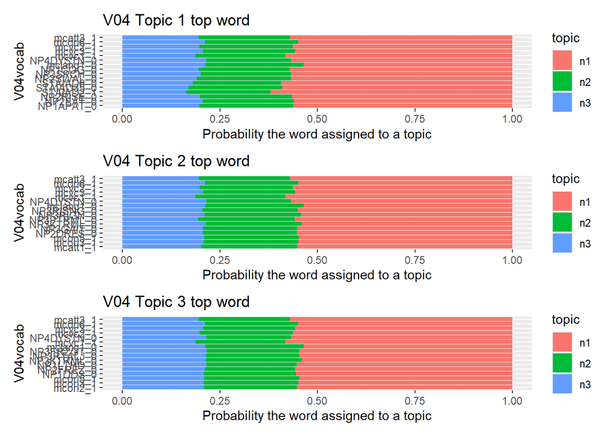

```r
# v04
V04topic = t(V04fit$topics)
colnames(V04topic) = c("n1", "n2", "n3")
V04vocab = rownames(V04topic)
V04topic = V04topic %>% as_tibble() %>%
  cbind(V04vocab)

## topic1
V04topic1 =V04topic %>% arrange(desc(n1))
V04topic1 = V04topic1[1:16,] %>%
  mutate(V04vocab = forcats::fct_reorder(V04vocab,n1)) %>%
  pivot_longer(n1:n3,names_to = "topic", values_to = "n")

V04plot1 = ggplot(V04topic1, aes(V04vocab,n, fill = topic )) +
  geom_bar(stat = "identity", position = "fill")+
  coord_flip() +
  labs(title = "V04 Topic 1 top word",
       y = "Probability the word assigned to a topic")

## topic2
V04topic2 =V04topic %>% arrange(desc(n2))
V04topic2 = V04topic2[1:16,] %>%
  mutate(V04vocab = forcats::fct_reorder(V04vocab,n2)) %>%
  pivot_longer(n1:n3,names_to = "topic", values_to = "n")
V04plot2 = ggplot(V04topic2, aes(V04vocab,n, fill = topic )) +
  geom_bar(stat = "identity", position = "fill")+
  coord_flip() +
  labs(title = "V04 Topic 2 top word",
       y = "Probability the word assigned to a topic")

## topic3
V04topic3 =V04topic %>% arrange(desc(n3))
V04topic3 = V04topic3[1:16,] %>%
  mutate(V04vocab = forcats::fct_reorder(V04vocab,n3)) %>%
  pivot_longer(n1:n3,names_to = "topic", values_to = "n")
V04plot3 = ggplot(V04topic3, aes(V04vocab,n, fill = topic )) +
  geom_bar(stat = "identity", position = "fill")+
  coord_flip() +
  labs(title = "V04 Topic 3 top word",
       y = "Probability the word assigned to a topic")


#v14

V14topic = t(V14fit$topics)
colnames(V14topic) = c("n1", "n2", "n3")
V14vocab = rownames(V14topic)
V14topic = V14topic %>% as_tibble() %>%
  cbind(V14vocab)

## topic1
V14topic1 =V14topic %>% arrange(desc(n1))
V14topic1 = V14topic1[1:16,] %>%
  mutate(V14vocab = forcats::fct_reorder(V14vocab,n1)) %>%
  pivot_longer(n1:n3,names_to = "topic", values_to = "n")

V14plot1 = ggplot(V14topic1, aes(V14vocab,n, fill = topic )) +
  geom_bar(stat = "identity", position = "fill")+
  coord_flip() +
  labs(title = "V14 Topic 1 top word",
       y = "Probability the word assigned to a topic")

## topic2
V14topic2 =V14topic %>% arrange(desc(n2))
V14topic2 = V14topic2[1:16,] %>%
  mutate(V14vocab = forcats::fct_reorder(V14vocab,n2)) %>%
  pivot_longer(n1:n3,names_to = "topic", values_to = "n")
V14plot2 = ggplot(V14topic2, aes(V14vocab,n, fill = topic )) +
  geom_bar(stat = "identity", position = "fill")+
  coord_flip() +
  labs(title = "V14 Topic 2 top word",
       y = "Probability the word assigned to a topic")

## topic3
V14topic3 =V14topic %>% arrange(desc(n3))
V14topic3 = V14topic3[1:16,] %>%
  mutate(V14vocab = forcats::fct_reorder(V14vocab,n3)) %>%
  pivot_longer(n1:n3,names_to = "topic", values_to = "n")
V14plot3 = ggplot(V14topic3, aes(V14vocab,n, fill = topic )) +
  geom_bar(stat = "identity", position = "fill")+
  coord_flip() +
  labs(title = "V14 Topic 3 top word",
       y = "Probability the word assigned to a topic")

V04plot1/V04plot2/V04plot3
```

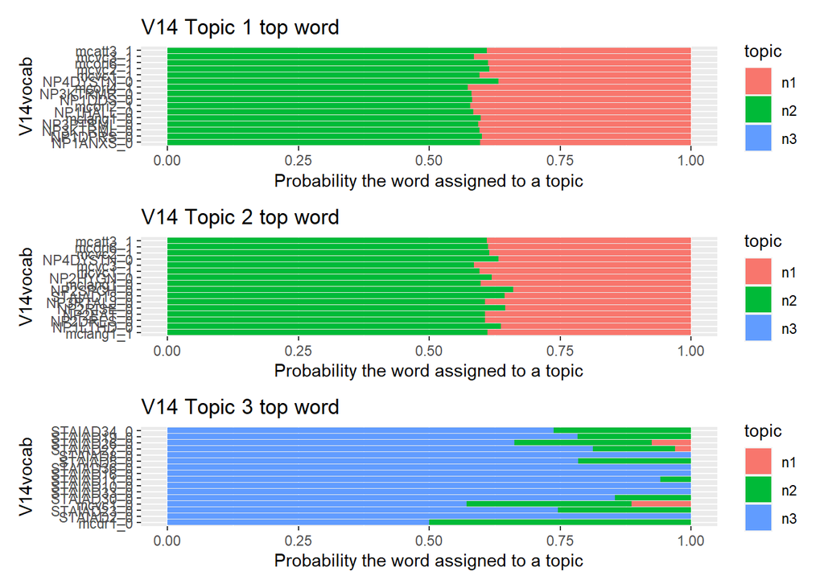

```r
V14plot1/V14plot2/V14plot3
```